# Unmasking Alternative Funding Programs Comparator Study

Authors

Ryan Moore

Department of Biostatistics

Vanderbilt University Medical Center

Published

October 20, 2025

# Study details

## Title

**Unmasking Alternative Funding Programs: Frequency and Impact of Specialty Medication Carve Out Models**

## Authors

Autumn Zuckerman, PharmD, BCPS, CSP<sup>1</sup>, Martha Stutsky<sup>2</sup>, Chloe Kim<sup>2</sup>, Rebecca Freedman<sup>3</sup>, Alicia Verret<sup>4</sup>, Taylor Lager<sup>4</sup>, Claire Ozoral<sup>4</sup>, Jennifer Loucks<sup>5</sup>, Stephanie Barrus<sup>6</sup>, Samantha Curry<sup>7</sup>, Kama Thomas<sup>7</sup>, Lisa Cristofaro<sup>8</sup>, Kristin Sigmon<sup>9</sup>, Darina Georgieva<sup>9</sup>, Jennifer Carter<sup>9</sup>, Diana Gabelman<sup>10</sup>, Alex Nelson<sup>10</sup>, Karen Thomas<sup>11</sup>, Katie Williford<sup>1</sup>, Amanda Kibbons<sup>1</sup>, Laura Moore<sup>1</sup>, Ryan Moore<sup>12</sup>, Leena Choi<sup>12</sup>

<sup>1</sup>Vanderbilt Specialty Pharmacy, Vanderbilt Health;  
<sup>2</sup>Shields Health Solutions;  
<sup>3</sup>Cleveland Clinic Specialty Pharmacy;  
<sup>4</sup>Ochsner Health;  
<sup>5</sup>University of Kansas Health System;  
<sup>6</sup>University of Utah Health;  
<sup>7</sup>Froedtert Health Pharmacy Solutions;  
<sup>8</sup>University of Rochester Medical Center;  
<sup>9</sup>Medical University of South Carolina;  
<sup>10</sup>MetroHealth System, Case Western Reserve University School of Medicine;  
<sup>11</sup>University of Illinois Chicago;  
<sup>12</sup>Department of Biostatistics, Vanderbilt University Medical Center

## Key findings

**Results from this multisite national study demonstrate that AFPs:**

- **Significantly reduce** the likelihood of accessing therapy
- **Significantly increase** time to treatment in patients able to access therapy
- **Take advantage of** manufacturer patient assistance programs (PAP) meant for uninsured or underinsured patients
- **Are associated with** more treatment gaps and adverse clinical outcomes compared to traditional pharmacy benefits
- **Increase complexity** in accessing life-altering specialty medication therapies, placing time and resource burdens on patients and pharmacy staff

# Analysis

## Demographics

| **Characteristic** | **N** | **AFP** **AFP**, N = 260<sup>1</sup> | **AFP** **Non-AFP**, N = 500<sup>1</sup> |
| --- | --- | --- | --- |
| Age | 716 |  |  |
| Mean (SD) |  | 46.3 (14.3) | 51.7 (16.9) |
| Median (IQR) |  | 49.0 (36.0 - 58.0) | 53.0 (40.0 - 64.0) |
| Range |  | 2.0 - 77.0 | 4.0 - 93.0 |
| Missing |  | 17 | 27 |
| Sex | 757 |  |  |
| Male |  | 93 (36.2%) | 239 (47.8%) |
| Female |  | 163 (63.4%) | 259 (51.8%) |
| Other |  | 1 (0.39%) | 2 (0.40%) |
| Missing |  | 3 | 0 |
| Ethnicity | 760 |  |  |
| Not Hispanic, Latino/a, or Spanish origin |  | 233 (89.6%) | 460 (92.0%) |
| Hispanic or Latino |  | 7 (2.69%) | 11 (2.20%) |
| Unknown |  | 1 (0.38%) | 0 (0%) |
| Decline to Answer |  | 3 (1.15%) | 11 (2.20%) |
| Mexican, Mexican American, or Chicano/a |  | 1 (0.38%) | 2 (0.40%) |
| Puerto Rican |  | 2 (0.77%) | 3 (0.60%) |
| Cuban |  | 0 (0%) | 1 (0.20%) |
| Other Hispanic, Latino/a, or Spanish origin |  | 4 (1.54%) | 3 (0.60%) |
| Not available |  | 9 (3.46%) | 9 (1.80%) |
| Race | 760 |  |  |
| White |  | 216 (83.1%) | 401 (80.2%) |
| Black or African American |  | 26 (10.0%) | 74 (14.8%) |
| American Indian or Alaska Native |  | 0 (0%) | 2 (0.40%) |
| Other Asian |  | 3 (1.15%) | 4 (0.80%) |
| Native Hawaiian or Other Pacific Islander |  | 2 (0.77%) | 0 (0%) |
| Other |  | 5 (1.92%) | 8 (1.60%) |
| Decline to Answer |  | 3 (1.15%) | 8 (1.60%) |
| Chinese |  | 0 (0%) | 1 (0.20%) |
| Vietnamese |  | 0 (0%) | 1 (0.20%) |
| Asian Indian |  | 1 (0.38%) | 0 (0%) |
| Not available |  | 4 (1.54%) | 1 (0.20%) |
| Clinic | 760 |  |  |
| Cardiology |  | 5 (1.92%) | 10 (2.00%) |
| Dermatology |  | 27 (10.4%) | 54 (10.8%) |
| Endocrinology |  | 5 (1.92%) | 10 (2.00%) |
| GI/IBD |  | 40 (15.4%) | 78 (15.6%) |
| Hepatology (non-hepatitis) |  | 3 (1.15%) | 6 (1.20%) |
| HIV |  | 9 (3.46%) | 18 (3.60%) |
| HCV |  | 3 (1.15%) | 6 (1.20%) |
| Other Infectious Diseases |  | 1 (0.38%) | 2 (0.40%) |
| Oncology/hematology |  | 49 (18.8%) | 95 (19.0%) |
| Non-MS Neurology |  | 7 (2.69%) | 12 (2.40%) |
| MS |  | 26 (10.0%) | 44 (8.80%) |
| Pediatric Inflammatory |  | 2 (0.77%) | 4 (0.80%) |
| Pediatric, Other |  | 0 (0%) | 0 (0%) |
| Pulmonology |  | 6 (2.31%) | 12 (2.40%) |
| Rheumatology |  | 62 (23.8%) | 122 (24.4%) |
| Transplant |  | 2 (0.77%) | 4 (0.80%) |
| Other |  | 13 (5.00%) | 23 (4.60%) |
| Referral Status | 760 |  |  |
| Continuing therapy |  | 146 (56.2%) | 276 (55.2%) |
| New medication |  | 114 (43.8%) | 224 (44.8%) |

<sup>1</sup> n (%)

## Medication Access and Time to Access

### Descriptive statistics

| **Characteristic** | **N** | **AFP** **AFP**, N = 260<sup>1</sup> | **AFP** **Non-AFP**, N = 500<sup>1</sup> |
| --- | --- | --- | --- |
| Medication access | 760 |  |  |
| Yes |  | 216 (83.1%) | 470 (94.0%) |
| No |  | 29 (11.2%) | 23 (4.60%) |
| Unsure |  | 10 (3.85%) | 6 (1.20%) |
| Unknown |  | 5 (1.92%) | 1 (0.20%) |
| Referral Outcome | 760 |  |  |
| Filled by a US pharmacy (original product or alternative) |  | 79 (30.4%) | 443 (88.6%) |
| Filled through manufacturer PAP |  | 85 (32.7%) | 24 (4.80%) |
| Filled by a non-US pharmacy |  | 42 (16.2%) | 0 (0%) |
| Medication changed to medical benefit medication |  | 8 (3.08%) | 15 (3.00%) |
| Patient lost to follow up during access process |  | 15 (5.77%) | 7 (1.40%) |
| Patient changed insurance to get medication approved |  | 15 (5.77%) | 0 (0%) |
| Nonstart- never accessed treatment |  | 7 (2.69%) | 3 (0.60%) |
| Therapy no longer needed/Pursued for clinical reasons during access process |  | 1 (0.38%) | 5 (1.00%) |
| Filled at HSSP covered by internal grant |  | 5 (1.92%) | 0 (0%) |
| Filled through Manufacturer Bridge Program |  | 2 (0.77%) | 1 (0.20%) |
| Filled using samples or internal supply |  | 1 (0.38%) | 1 (0.20%) |
| Other |  | 0 (0%) | 1 (0.20%) |
| Time to access | 698 |  |  |
| Mean (SD) |  | 41.3 (34.1) | 14.6 (18.0) |
| Median (IQR) |  | 31.5 (18.0 - 55.0) | 8.0 (5.0 - 16.0) |
| Range |  | 0.0 - 184.0 | 0.0 - 129.0 |
| Applied for manufacturer patient assistance programs (PAP) | 760 |  |  |
| No |  | 90 (34.6%) | 452 (90.4%) |
| Yes |  | 170 (65.4%) | 48 (9.60%) |
| PAP approved | 225 |  |  |
| Yes |  | 85 (48.0%) | 40 (83.3%) |
| No |  | 92 (52.0%) | 8 (16.7%) |
| PAP denial reason | 100 |  |  |
| Identified AFP enrollment |  | 39 (44.8%) | 0 (0%) |
| Unknown |  | 23 (26.4%) | 0 (0%) |
| Other |  | 15 (17.2%) | 6 (46.2%) |
| Overqualified financially |  | 7 (8.05%) | 4 (30.8%) |
| Incomplete PAP enrollment paperwork |  | 3 (3.45%) | 3 (23.1%) |
| PA submitted | 755 |  |  |
| Yes |  | 190 (73.1%) | 296 (59.8%) |
| No |  | 70 (26.9%) | 199 (40.2%) |
| Appeal submitted | 121 |  |  |
| No |  | 63 (72.4%) | 12 (35.3%) |
| Yes |  | 24 (27.6%) | 22 (64.7%) |

<sup>1</sup> n (%)

### Figures

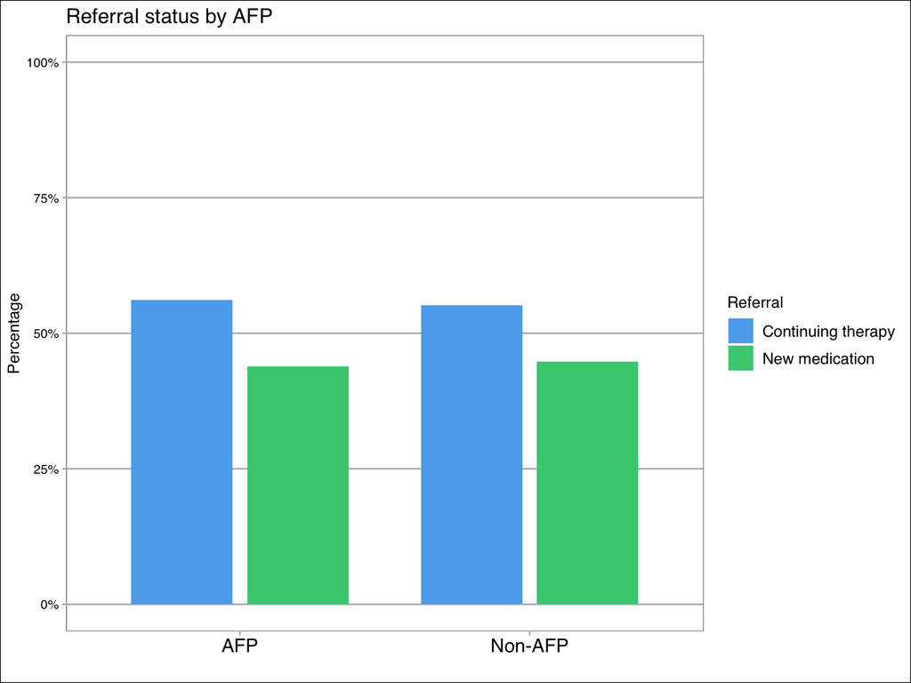

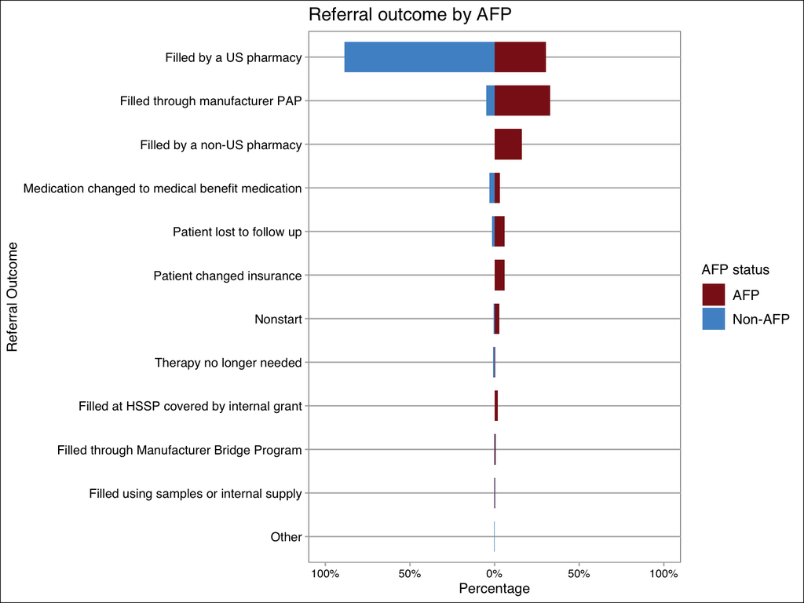

### Medication access analysis

[output not shown]

<sup>1</sup> n (%)

Mixed-Effects Logistic Regression Results: Medication Access (Unknown is dropped)

| Term | Log(OR) | Odds Ratio | 95% CI for OR Lower | 95% CI for OR Upper | P-value |
| --- | --- | --- | --- | --- | --- |
| Intercept | 2.294 | 9.914 | 4.224 | 23.267 | <0.001 |
| AFP status: Non-AFP vs AFP | 1.163 | 3.200 | 1.755 | 5.835 | <0.001 |
| Referral: New vs continuing | -0.673 | 0.510 | 0.273 | 0.953 | 0.035 |

### Time to medication access analysis

#### Descriptive statistics

| **Group** | **Non-AFP / Continuing therapy**, N = 276 | **AFP / Continuing therapy**, N = 146 | **Non-AFP / New medication**, N = 224 | **AFP / New medication**, N = 114 |
| --- | --- | --- | --- | --- |
| time_to_access |  |  |  |  |
| Median [IQR] (range: Range) | 7.0 [4.0, 14.0] (range: 0.0, 117.0) | 33.5 [14.3, 55.8] (range: 0.0, 184.0) | 11.0 [5.0, 21.0] (range: 0.0, 129.0) | 29.0 [19.0, 53.5] (range: 2.0, 155.0) |
| Unknown | 1 | 20 | 17 | 24 |

#### Survival Model

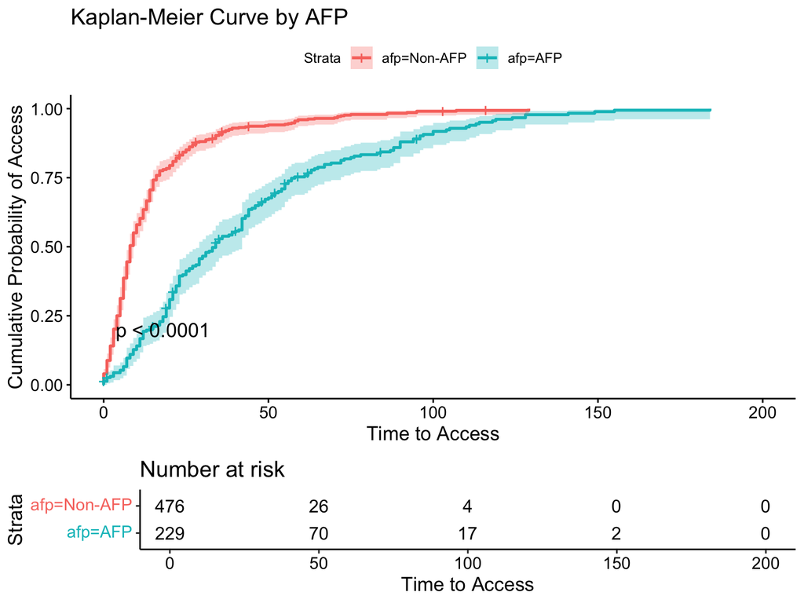

Cox proportional hazards with site frailty (HR > 1 = faster access)

| Term | HR | 95% CI | p-value |
| --- | --- | --- | --- |
| AFP status: Non-AFP vs AFP | 3.37 | [2.82, 4.03] | <0.001 |
| Referral: New vs continuing | 0.86 | [0.72, 1.01] | 0.068 |

#### Figures

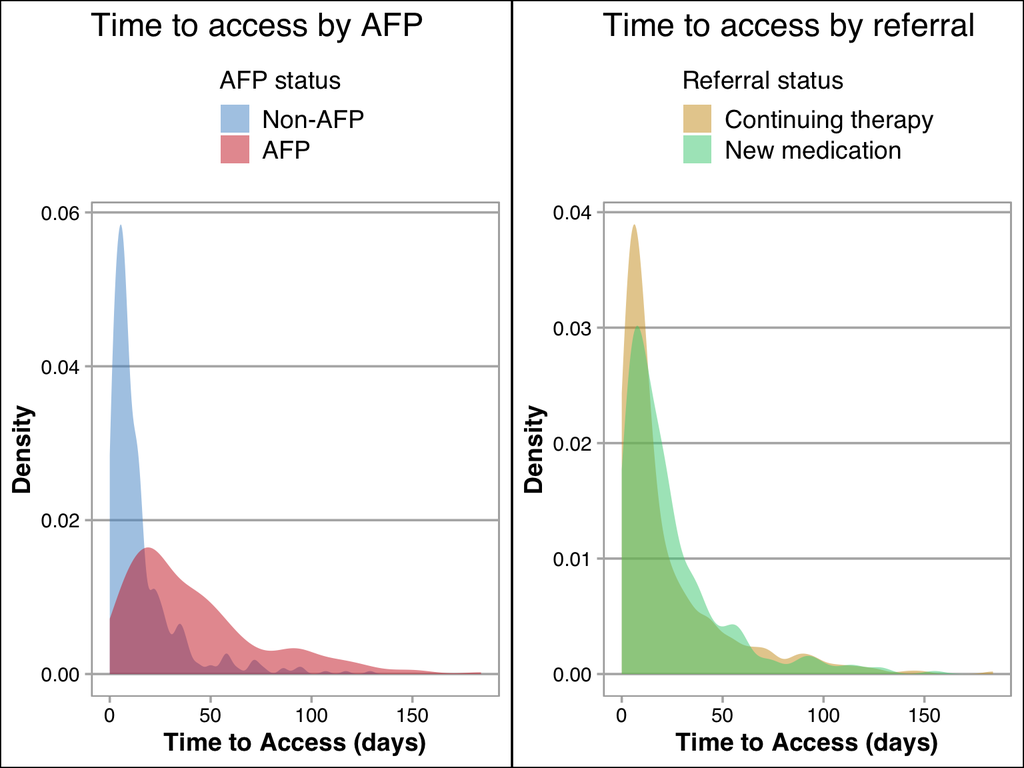

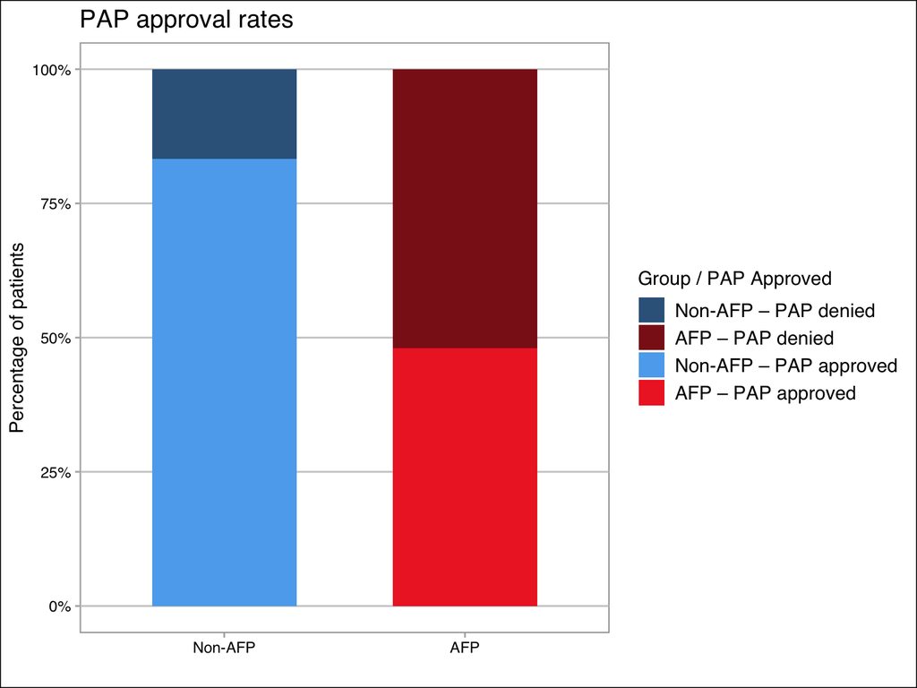

## Treatment Gaps and Urgent Supply Use

| **Characteristic** | **N** | **afp** **Non-AFP**, N = 500<sup>1</sup> | **afp** **AFP**, N = 260<sup>1</sup> |
| --- | --- | --- | --- |
| Treatment gap | 428 |  |  |
| No |  | 265 (94.0%) | 79 (54.1%) |
| Yes |  | 5 (1.77%) | 51 (34.9%) |
| Unknown |  | 12 (4.26%) | 16 (11.0%) |
| Missing |  | 218 | 114 |
| Samples provided | 760 |  |  |
| No |  | 474 (94.8%) | 219 (84.2%) |
| Yes |  | 10 (2.00%) | 31 (11.9%) |
| Unsure |  | 16 (3.20%) | 10 (3.85%) |
| Courtesy fill provided | 259 |  |  |
| No |  | 0 (NA%) | 168 (64.9%) |
| Not needed or requested |  | 0 (NA%) | 53 (20.5%) |
| Yes |  | 0 (NA%) | 38 (14.7%) |
| Missing |  | 500 | 1 |

<sup>1</sup> n (%)

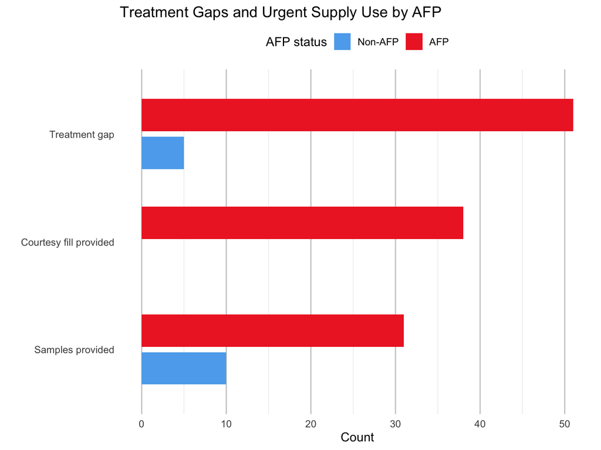

## Poor clinical outcomes

| **Characteristic** | **N** | **afp** **Non-AFP**, N = 500<sup>1</sup> | **afp** **AFP**, N = 260<sup>1</sup> |
| --- | --- | --- | --- |
| Any poor clinical outcomes | 760 |  |  |
| No poor clinical outcome |  | 493 (98.6%) | 232 (89.2%) |
| Poor clinical outcome |  | 7 (1.40%) | 28 (10.8%) |

<sup>1</sup> n (%)

**Poor clinical outcome description**

[output not shown]

<sup>1</sup> n (%)

## Human resources communications

**HR communication descriptions**

| **Characteristic** | **N** | **afp** **Non-AFP**, N = 500<sup>1</sup> | **afp** **AFP**, N = 260<sup>1</sup> |
| --- | --- | --- | --- |
| Communicated with HR dept about access process | 257 |  |  |
| Yes |  | 0 (NA%) | 19 (7.39%) |
| No |  | 0 (NA%) | 84 (32.7%) |
| Unknown |  | 0 (NA%) | 154 (59.9%) |
| Missing |  | 500 | 3 |

<sup>1</sup> n (%)

| **Characteristic** | **N = 757**<sup>1</sup> |
| --- | --- |
| Appeal to override AFP process | 10 (1.32%) |
| Voiced concern about the AFP process | 5 (0.66%) |
| Discussed explanation of benefits/AFP process | 5 (0.66%) |
| Other | 1 (0.13%) |
| Unknown | 3 (0.40%) |

<sup>1</sup> n (%)

## Pharmacy Staff Time

### Descriptive statistics

| **Characteristic** | **N** | **afp** **Non-AFP**, N = 500 | **afp** **AFP**, N = 260 |
| --- | --- | --- | --- |
| Pharmacist time spent on access process | 749 |  |  |
| Mean (SD) |  | 1.1 (1.0) | 3.7 (3.8) |
| Median (IQR) |  | 1.0 (0.5 - 1.5) | 2.0 (1.0 - 4.0) |
| Range |  | 0.0 - 8.0 | 0.5 - 30.0 |
| Missing |  | 1 | 10 |

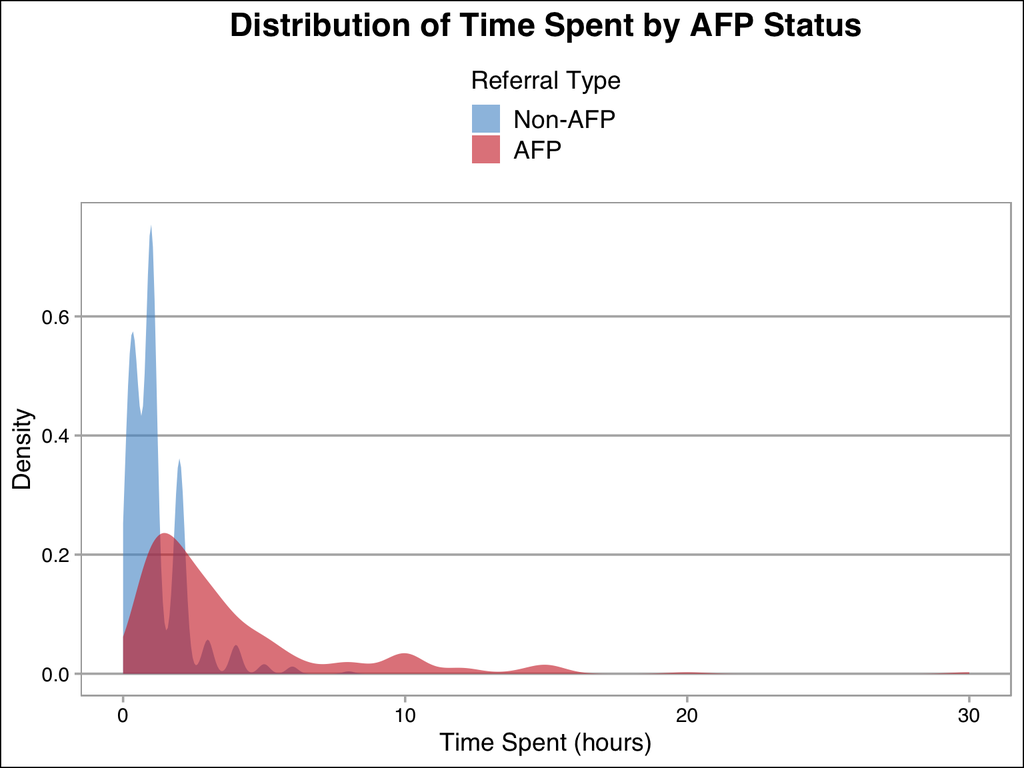

### Cummulative link mixed model

Cumulative Link Mixed Model Results

| Term | Log(OR) | Odds Ratio | 95% CI for OR Lower | 95% CI for OR Upper | P-value |
| --- | --- | --- | --- | --- | --- |
| AFP status: AFP vs Non-AFP | 2.225 | 9.249 | 6.653 | 12.858 | <0.001 |
| Referral: New vs continuing | 0.301 | 1.351 | 1.024 | 1.782 | 0.034 |

## AFP Identification

| **Characteristic** | **N** | **N = 261**<sup>1</sup> |
| --- | --- | --- |
| Method of AFP Identification | 254 |  |
| Access approved, but forced to sign up for AFP |  | 72 (28.3%) |
| Access approved, patient must apply for PAP |  | 1 (0.39%) |
| Access denied, patient must apply for PAP |  | 6 (2.36%) |
| Access denied, patient must contact AFP |  | 55 (21.7%) |
| AFP contacted clinic for therapy change |  | 2 (0.79%) |
| AFP contacted clinic to apply for PAP |  | 11 (4.33%) |
| AFP contacted patient directly |  | 7 (2.76%) |
| Identified by PAP |  | 9 (3.54%) |
| No option to submit PA or appeal, directed to PAP |  | 45 (17.7%) |
| On BI, ineligible for HSSP, contact AFP |  | 30 (11.8%) |
| Prescription required to be sent internationally |  | 14 (5.51%) |
| Unknown |  | 2 (0.79%) |
| Missing |  | 7 |

<sup>1</sup> n (%)

# Patient Stories

### Common scenarios experienced by pharmacy staff

- Lack of communication or inability to reach AFP
- Required to apply for manufacturer PAP as first step
- Use of “shell pharmacies” – U.S. pharmacies that source product internationally
- Fills or shipments not authorized by the prescribing provider or from an unknown provider
- Delays with international deliveries and medication destruction at the border

### Patient 1 – 34-year-old, Stage IV colorectal cancer

- PA submitted → denied (no appeal process)
- Required to apply for PAP → denied (AFP enrollment)
- Required passport and telehealth with PriceMD (not cancer provider)
- Received 3-month supply from international pharmacy  
  **Time to access:** ~5 months **PharmD time:** 15 hours

### Patient 2 – 51-year-old, severe Crohn’s disease

- PA submitted → denied (no appeal option)
- Required to apply for PAP → denied
- IV re-induction required
- Appeal to AFP → approved for Canadian pharmacy fill
- Canadian worker strike delayed delivery
- Temporary U.S. pharmacy fill allowed  
  **Time to access:** ~5 months **PharmD time:** 10 hours

### Patient 3 – 55-year-old, primary biliary cirrhosis

- PAP denied → required Medicaid → denied → re-applied → denied again
- Allowed to fill at Accredo with Foundation grant and maximizer program  
  **Time to access:** 1 month **PharmD time:** 6 hours

### Patient 4 – 55-year-old, severe Crohn’s disease

- 1st PAP denied → 2nd PAP denied
- U.S. pharmacy Rx filled internationally  
  **Time to access:** 2 months **PharmD time:** 2 hours

### Patient 5 – 33-year-old, ulcerative pancolitis

- PA approved
- Samples provided after 19 days without response
- AFP requested 3-month supply
- Another sample sent; received medication via international pharmacy  
  **Time to access:** 2 months **PharmD time:** 3 hours

### Patient 6 – 35-year-old, ulcerative pancolitis

- AFP, Accredo, and Cigna each waiting on one another
- AFP eventually approved Accredo fill  
  **Time to access:** 2 months **PharmD time:** 1.5 hours

### Patient 7 – 50-year-old, severe psoriasis

- PA denied → PAP denied → appeal approved
- One fill at Kroger; maintenance from GlobalRx (Canada, NZ, Australia, England)  
  **Time to access:** 3 weeks **PharmD time:** 4 hours

### Patient 8 – 36-year-old, severe Crohn’s disease

- Mid-year insurance change required Intercept Rx
- Provider faxed new Rx (e-scribe not accepted)
- Medication shipped from Canada by unknown provider  
  **Time to access:** 3 weeks **PharmD time:** 2 hours

### Patient 9 – 63-year-old, mantle cell lymphoma

- Initial fill via GlobalRx (Australia)
- Refill halted due to tariffs; AFP allowed one-time U.S. override
- Refill delays ≥ 3 weeks  
  **Time to access refill:** > 1 month **PharmD time:** 0.5 hours

### Acknowledgements

This study was completed by the **Vanderbilt Health System Specialty Pharmacy Outcomes Research Consortium**, including:  
Vanderbilt Health, Shields Health Solutions, Ochsner Health, Cleveland Clinic Specialty Pharmacy, Froedtert Health Pharmacy Solutions, University of Utah Health, Medical University of South Carolina, University of Kansas Health System, Cleveland Clinic Foundation, MetroHealth System, University of Rochester Medical Center, and University of Illinois Chicago.

This work was supported by Vanderbilt University Medical Center biostatisticians **Ryan Moore, MS**, and **Leena Choi, PhD**.

*Note:* Data collection continued through 2025. Analyses are ongoing, and a manuscript including 2024–2025 data is anticipated in **Fall 2026**.